# Tutorial3: Muestreando del *prior*

Sandra Reinales & Gustavo Ballen

Muestrear del *prior* (*sample from prior*), es decir, correr un análisis de `MCMCtree` sin datos provenientes de las secuencia (`usedata = 0`) es crucial para examinar las medias y los intervalos de confianza (incertidumbre) de los tiempos de divergencia especificados en la distribución *prior*. Esto es importante porque la distribución *prior* usada por `MCMCtree` en el análisis, también llamada **prior efectivo**, difiere de la distribución definida por el usuario. Ese *prior* efectivo es generado por el programa después de conjugar todas las densidades de calibración especificadas por el usuario con el proceso birth-death del árbol (incluyendo los valores de los parámetros especificados en BDparas).La distribución *prior* resultante es una densidad marginal. A veces puede ser necesario modificar la especificación de los *priors* de calibración para que el prior efectivo parezca más razonable.

Vamos a crear un directorio para el análisis, y a copiar el *control file*:

```bash
## Asumiendo que estamos en el directorio princial del repositorio
mkdir -p sFRp
cp data/mcmctree.ctl sFRp/
```

Ahora vamos a editar el *control file* para usar el modelo de reloj independiente ILN. Nuestro *control file* ya está configurado en `usedata=0`.

```bash
cd sFRp

## Definir clock
sed -r -i 's/clock = 1/clock = 2/g' mcmctree.ctl

## Revisemos
less mcmctree.ctl

## Corramos `MCMCtree`
mcmctree
```

Ahora vamos a comparar la distribución *prior* designada por nosotros con la densidad de calibración que va a ser usada por el programa (i.e. *prior* efectivo). Más adelante podremos comparar también esas densidades *prior* con la posterior para detectar interdependencia o algún sesgo específico.

Primero vamos a leer el archivo de salida de `mcmctree` en `R`:

```r
## Cargar los paquetes
library(ape)
library(tbea)
library(mcmc3r)
```

Grafiquemos de nuevo el *prior* de calibración que definimos para este nodo en el tutorial1

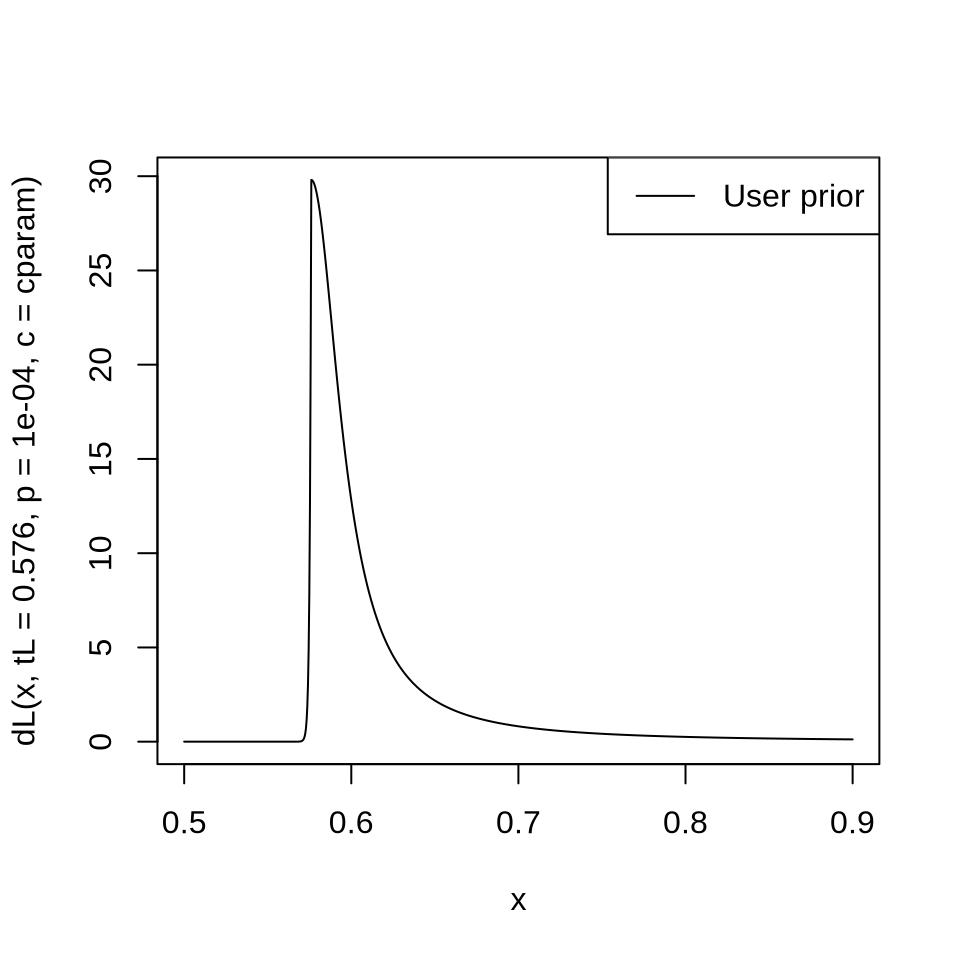

```r
## Recordemos que el valor del parametro c de la distribucion L
## para el nodo de Istiophoridae
cparam <- 0.03609402

curve(dL(x, tL=0.57600, p=0.0001, c=cparam),
      from=0.5, to=0.9, n=1000)
legend(x="topright", legend="User prior", col="black", lty=1)
```

Ahora usemos la muestra posterior del análisis *sample from prior* para ese nodo:

```r
## Leer el archivo
prior <- read.delim("sFRp/mcmc.txt")
head(prior[,c(1:7)])
```

```
##   Gen     t_n54     t_n55     t_n56     t_n57     t_n58     t_n59
## 1   1 0.9916192 0.9590438 0.9263390 0.7609529 0.7367989 0.4996686
## 2   6 0.9688622 0.9551809 0.9384186 0.8873584 0.8309910 0.4996686
## 3  12 0.9905945 0.9691800 0.9546229 0.8302722 0.6306099 0.0667782
## 4  18 0.9905945 0.9692914 0.9377121 0.6986783 0.6368693 0.3826717
## 5  24 0.9532588 0.9417476 0.8786269 0.5796155 0.4252539 0.3682487
## 6  30 0.9532588 0.9505510 0.9147055 0.7671669 0.6191564 0.3929008
```

Debido a que `MCMCtree` nombra nuevamente los nodos de la filogenia, vamos a graficar el árbol de salida que está en el archivo `out.log` para entender la correspondencia de los nodos.

```bash
## Asumiendo que estamos en sFRp
grep -n "Species tree for FigTree" out.log # Buscamos la linea donde esta el arbol
sed -n '1045p' out.log > out.tre # Extraemos la informacion del arbol y la copiamos en un nuevo archivo

## Usamos figtree para graficar el arbol y activamos los node labels
figtree out.tre
```

Volvemos a `R`:

```r
## Vamos a construir una densidad con los valores de distribucion posterior
effPriorIstiopho <- density(prior$t_n57)
print(effPriorIstiopho)
```

```
##
## Call:
##  density.default(x = prior$t_n57)
##
## Data: prior$t_n57 (20001 obs.);  Bandwidth 'bw' = 0.003555
##
##        x                y
##  Min.   :0.5021   Min.   : 0.00010
##  1st Qu.:0.6512   1st Qu.: 0.02804
##  Median :0.8002   Median : 0.23316
##  Mean   :0.8002   Mean   : 1.67390
##  3rd Qu.:0.9493   3rd Qu.: 1.11066
##  Max.   :1.0983   Max.   :16.11425
```

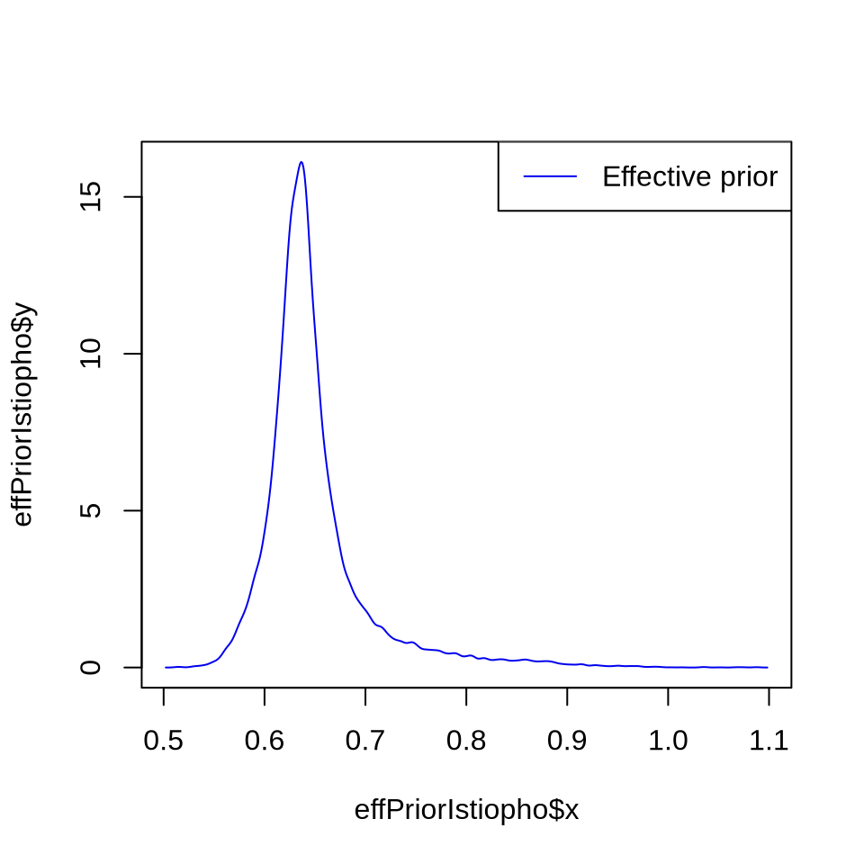

```r
## Ahora dibujemos el prior efectivo sobre el prior del usuario
plot(x=effPriorIstiopho$x, y=effPriorIstiopho$y, type="l", col="blue2")
legend(x="topright", legend="Effective prior", col="blue2", lty=1)
```

**Cómo lucen los demás nodos calibrados?**